# Peer Assignment 1

Sergio Astorga

9th March 2016

This is the report for the Assignment corresponding to the Course Reproducible Research in Coursera.

Some of the functions used in this code needs the next packages:

```r
library(plyr)
library(dplyr)
```

```r
library(ggplot2)
```

### Loading and preprocessing the data

To load the data, the file “activity.csv” must be cointained in your session or working directory. Then, simply execute the code:

```r
setwd("C:\\Users\\Alcampo\\Dropbox\\Cursos\\Big Data\\5.- Reproducible Research\\Assignment 1\\Report")
data <- read.csv("activity.csv", header = TRUE)
head(data)
```

```
##   steps       date interval
## 1    NA 2012-10-01        0
## 2    NA 2012-10-01        5
## 3    NA 2012-10-01       10
## 4    NA 2012-10-01       15
## 5    NA 2012-10-01       20
## 6    NA 2012-10-01       25
```

Activities dataset will be stored in “data”.

### What is mean total number of steps taken per day?

To calculate the total number of steps taken per day the next code was performed:

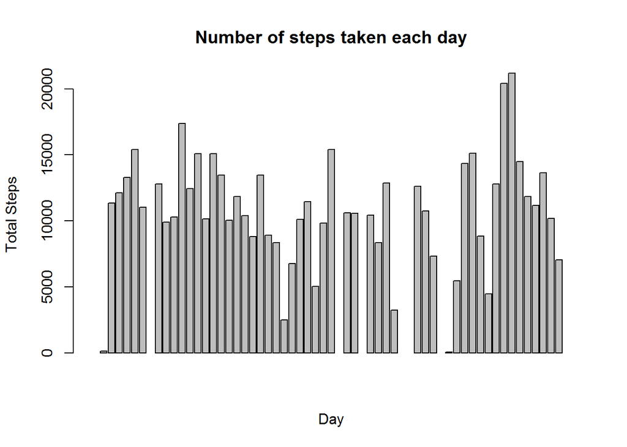

```r
stepsByDay <- with(data, aggregate(steps, by = list(date), FUN = sum))
barplot(stepsByDay$x, xlab = "Day", ylab = "Total Steps", main = "Number of steps taken each day")
```

```r
stepsByDay$x
```

```
##  [1]    NA   126 11352 12116 13294 15420 11015    NA 12811  9900 10304
## [12] 17382 12426 15098 10139 15084 13452 10056 11829 10395  8821 13460
## [23]  8918  8355  2492  6778 10119 11458  5018  9819 15414    NA 10600
## [34] 10571    NA 10439  8334 12883  3219    NA    NA 12608 10765  7336
## [45]    NA    41  5441 14339 15110  8841  4472 12787 20427 21194 14478
## [56] 11834 11162 13646 10183  7047    NA
```

The mean and the median are:

```r
summary(stepsByDay$x)[4]
```

```
##  Mean
## 10770
```

```r
summary(stepsByDay$x)[3]
```

```
## Median
##  10760
```

### What is the average daily activity pattern?

The average daily activity pattern is assessed through next code:

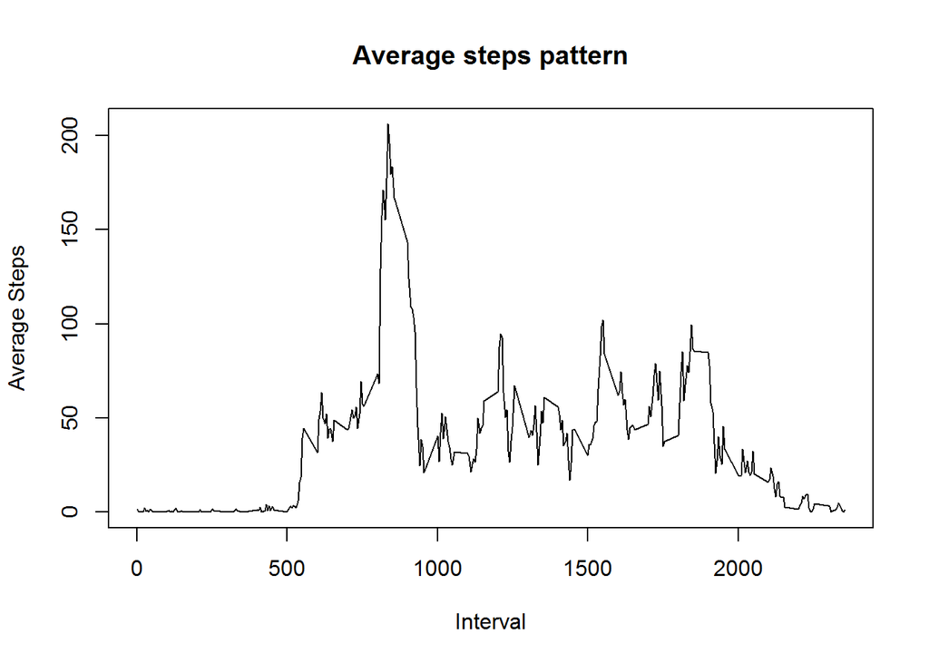

```r
AvStepsByDay <- with(data, aggregate(steps, by = list(interval), FUN = mean, na.rm = TRUE))
plot(AvStepsByDay$Group.1, AvStepsByDay$x, type = "l", xlab = "Interval", ylab = "Average Steps", main = "Average steps pattern")
```

First row makes the average of each interval through the days. The second one plots graphically the average through the five minutes interval. Last row calculates the interval where the number of steps is maximum, which in this case is:

- Max Interval = 8:35

```r
names(AvStepsByDay) <- c("interval","steps")
AvStepsByDay[AvStepsByDay$steps == max(AvStepsByDay$steps),]
```

```
##     interval    steps
## 104      835 206.1698
```

### Imputing missing values

There are some missing values at the Steps variable, its name is given by:

- NA = 2304

```r
sum(is.na(data$steps))
```

```
## [1] 2304
```

To remove missing values, an average of the steps through all days is calculated. This vector called “MeanStepsByDay” is assign to the days where data is missing. The code to assign the missing values is the next one:

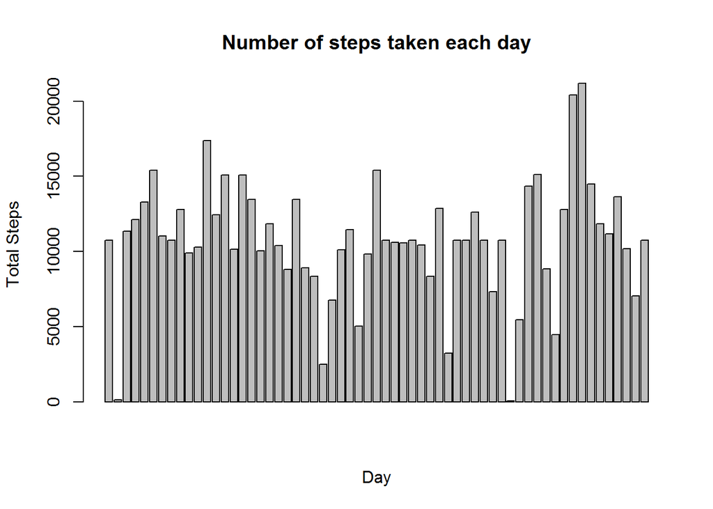

```r
MeanStepsByDay <- with(data, aggregate(steps, by = list(interval), FUN = mean, na.rm = TRUE))
vect <- is.na(data$steps)
vect2 <- rep(MeanStepsByDay$x, length(vect)/length(MeanStepsByDay$x))
newData <- cbind(vect2, vect)
newData <- cbind(data, newData)
newData$steps[is.na(newData$steps)] <- 0
newData <- mutate(newData, steps = vect2*vect + steps)
newData <- newData[c("steps", "date", "interval")]
newStepsByDay <- with(newData, aggregate(steps, by = list(date), FUN = sum))
barplot(newStepsByDay$x, xlab = "Day", ylab = "Total Steps", main = "Number of steps taken each day")
```

Last rows in the code creates a a histogram of the total number of steps taken each day.

To asses the mean and the median of the new dataset, it is used:

- summary(newStepsByDay$x)[4] -> Mean = 10770
- summary(newStepsByDay$x)[3] -> Median = 10770

```r
summary(newStepsByDay$x)[4]
```

```
##  Mean
## 10770
```

```r
summary(newStepsByDay$x)[3]
```

```
## Median
##  10770
```

Imputing missing values increases the Median but not the Mean in less than 0.1%.

### Are there differences in activity patterns between weekdays and weekends?

To describe the difference between “weekdays” and “weekends” a factor variable was created and “ggplot2” package was used. The code implemented is shown now:

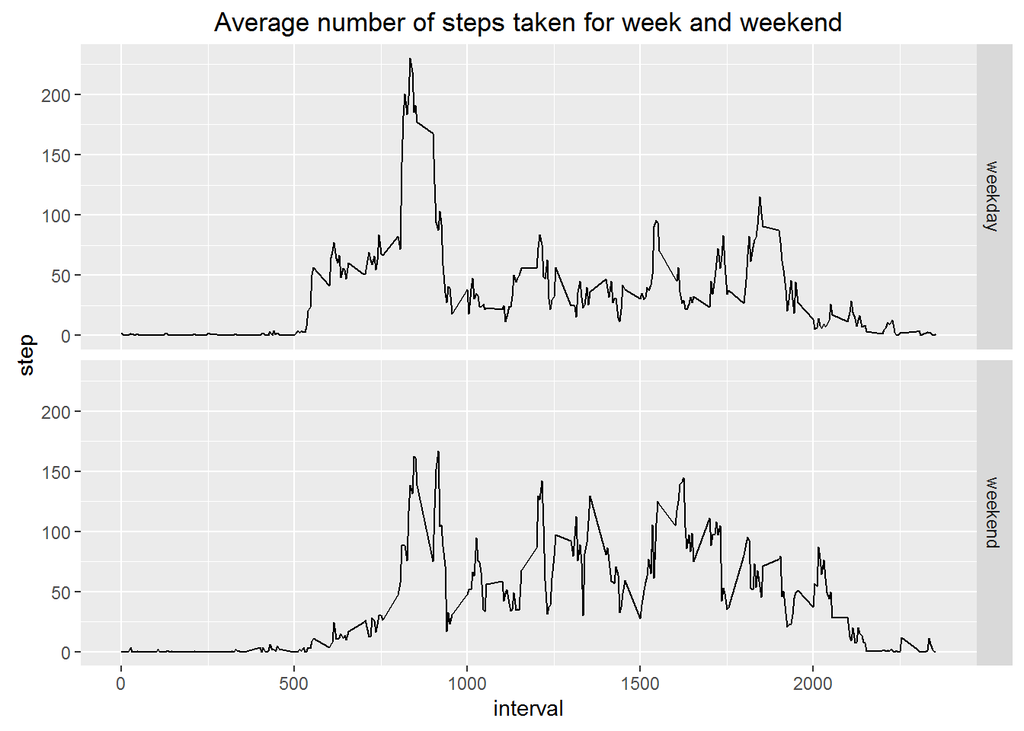

```r
factVar <- as.POSIXlt(as.Date(newData$date))$wday
factVar[factVar>0 & factVar<6] <- "weekday"
factVar[factVar != "weekday"] <- "weekend"
factVar <- as.factor(factVar)

newData2 <- cbind(newData, factVar)
newData2 <- group_by(newData2, factVar, interval)
results <- summarise(newData2, step = mean(steps))

p <- qplot(interval, step, data = results, facets = factVar~., geom = "line", main = "Average number of steps taken for week and weekend")
plot(p)
```

First paragraph converts dates in the dataset to a factor whose levels are “weekday” and “weekend”. Second paragraph just assess the mean for the steps attending to the “weekday” and “weekend” factors. Last rows displays the results for the mean on “weekday” and “weekend”.

## Code Script

```r
# Assignment 1
library(plyr)
library(dplyr)
library(ggplot2)
setwd("C:\\Users\\Alcampo\\Dropbox\\Cursos\\Big Data\\5.- Reproducible Research\\Assignment 1\\Report")

data <- read.csv("activity.csv", header = TRUE)

# What is mean total number of steps taken per day?
stepsByDay <- with(data, aggregate(steps, by = list(date), FUN = sum))
png(filename = "plot1.png",
    width = 480, height = 480, units = "px")
barplot(stepsByDay$x, xlab = "Day", ylab = "Total Steps", main = "Number of steps taken each day")
dev.off()
```

```r
summary(stepsByDay$x)[4]
```

```
##  Mean
## 10770
```

```r
summary(stepsByDay$x)[3]
```

```
## Median
##  10760
```

```r
# R: mean = 10770, median = 10760

# What is the average daily activity pattern?
AvStepsByDay <- with(data, aggregate(steps, by = list(interval), FUN = mean, na.rm = TRUE))
png(filename = "plot2.png",
    width = 480, height = 480, units = "px")
plot(AvStepsByDay$Group.1, AvStepsByDay$x, type = "l", xlab = "Interval", ylab = "Average Steps", main = "Average steps pattern")
dev.off()
```

```r
AvStepsByDay$Group.1[AvStepsByDay$x == max(AvStepsByDay$x)]
```

```
## [1] 835
```

```r
# R: In interval 835 is where the maximum average number of steps is reached

# Imputing missing values
sum(is.na(data$steps))
```

```
## [1] 2304
```

```r
MeanStepsByDay <- with(data, aggregate(steps, by = list(interval), FUN = mean, na.rm = TRUE))
vect <- is.na(data$steps)
vect2 <- rep(MeanStepsByDay$x, length(vect)/length(MeanStepsByDay$x))
newData <- cbind(vect2, vect)
newData <- cbind(data, newData)
newData$steps[is.na(newData$steps)] <- 0
newData <- mutate(newData, steps = vect2*vect + steps)
newData <- newData[c("steps", "date", "interval")]
newStepsByDay <- with(newData, aggregate(steps, by = list(date), FUN = sum))
png(filename = "plot3.png",
    width = 480, height = 480, units = "px")
barplot(newStepsByDay$x, xlab = "Day", ylab = "Total Steps", main = "Number of steps taken each day")
dev.off()
```

```r
summary(newStepsByDay$x)[4]
```

```
##  Mean
## 10770
```

```r
summary(newStepsByDay$x)[3]
```

```
## Median
##  10770
```

```r
# R: Missing values 2304. mean = 10770, median = 10770. Imputing missing data influenced on the median value

# Are there differences in activity patterns between weekdays and weekends?
factVar <- as.POSIXlt(as.Date(newData$date))$wday
factVar[factVar>0 & factVar<6] <- "weekday"
factVar[factVar != "weekday"] <- "weekend"
factVar <- as.factor(factVar)

newData2 <- cbind(newData, factVar)
newData2 <- group_by(newData2, factVar, interval)
results <- summarise(newData2, step = mean(steps))

p <- qplot(interval, step, data = results, facets = factVar~., geom = "line", main = "Average number of steps taken for week and weekend")
png(filename = "plot4.png",
    width = 480, height = 480, units = "px")
plot(p)
dev.off()
```